# 06_08_2020

## The Daily Graph

```
          06/08/2020
```

*Introduction*  
I have added Hamilton County, Ohio to the list of counties followed. Although none of the family live there, Campbell County, KY is just across the Ohio River and there is a possibility we will end up there.  
I've included some analyses of the moving averages of the number of new confirmed cases daily.  
I think I will continue to post for a while, but probably less than daily. (I could rename -- The Occaisional Graph).  
Suggestions for clarification or expansion are always welcome -- text or email.

| Statistic | Campbell, KY | Fulton, GA | Hamilton, OH | Hartford, CT | Leon, FL | Suffolk, NY |
| --- | --- | --- | --- | --- | --- | --- |
| Population | 93,584 | 1,063,937 | 817,473 | 891,720 | 293,582 | 1,476,601 |
| Cases | 196 | 4,823 | 2,860 | 10,809 | 442 | 40,329 |
| Deaths | 12 | 252 | 171 | 1,287 | 7 | 1,931 |
| Cases per 100,000 | 209 | 453 | 349 | 1212 | 150 | 2731 |
| Deaths per 100,000 | 12 | 23 | 20 | 144 | 2 | 130 |
| Date of first case | 3/24/20 | 3/3/20 | 3/19/20 | 3/14/20 | 3/19/20 | 3/8/20 |

### Summary for selected counties

The lowest reported confirmed cases per 100,000 population is Leon County followed (in increasing order) by Campbell County, Hamilton County, Fulton County, Hartford County, and Suffolk county.

The only difference in the ordering of the death rates is that the death rate in Hartford county is higher than that in Suffolk county.

As I noted earlier, it appears that at least part of low death rate in Leon County is due to a Florida requirement in the definition of a confirmed case

A graph of the evolution of the number per 100,000 confirmed cases shows similar results, in terms of ordering, pretty much after the few initial days of reporting.

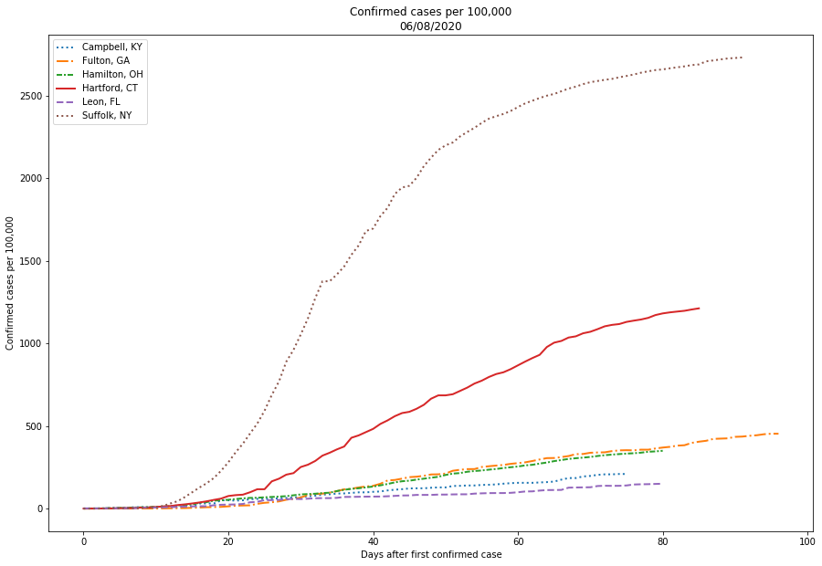

*Log rate of occurrence*  
Recall that if the occurrence was expontial, the semi-log graph would be linear. This doesn't occur in any of the counties. After about 30 days, Hamilton and Fulton counties are extremely similar. Suffolk county has, at least almost, reached a plateau (meaning very few new cases). We will see verification of this later when we examine trends in the number of new confirmed cases. The rest of the counties seem to be continuing to increase although Hartford county seems to be reaching a plateau (we see this again, later).

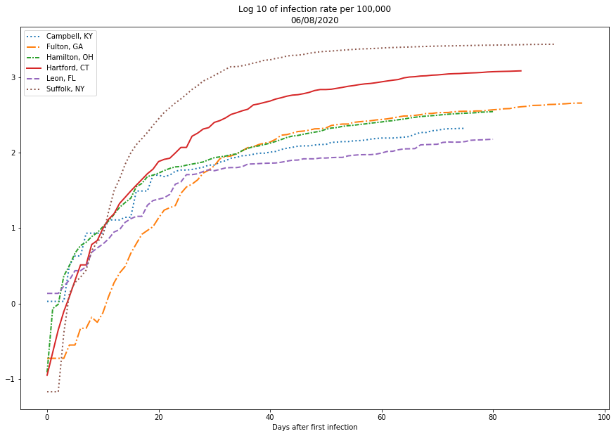

*Examining estimated doubling time*  
Although the overall curves can't be classified by a single exponential model. A piecewise examination allows us to estimate doubling time, how long at the present rate will it take to have twice the number of cases. If we select k consecutive days and assume that within that time frame that $\log(y)=\beta_0 + \beta_1 * t$. Then the time it takes to double the number of cases is $\frac{\log_{10}(2)}{\beta_1}$.  
I used three analyses of doubling time estimated using 5 , 7, and 10 days.

In each case I started with day 0 and took the $k$ days including it and estimated $\beta$ ($k = 5, 7, 10$). I then took the next $k$ days starting with day $k$ and so on until there were less that $k$ days left. For each of these time frames, I estimate $\beta$ assuming exponential growth and plotted the resulting estimates of doubling time in the graphs.

This examination has the advantage if putting the estimated growth on a somewhat intuitive scale. The larger the doubling time the slower the rate of increase.

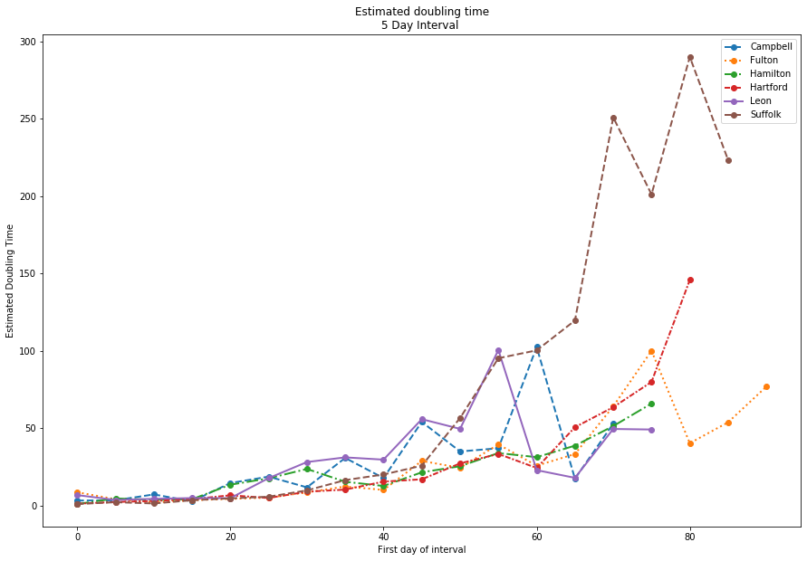

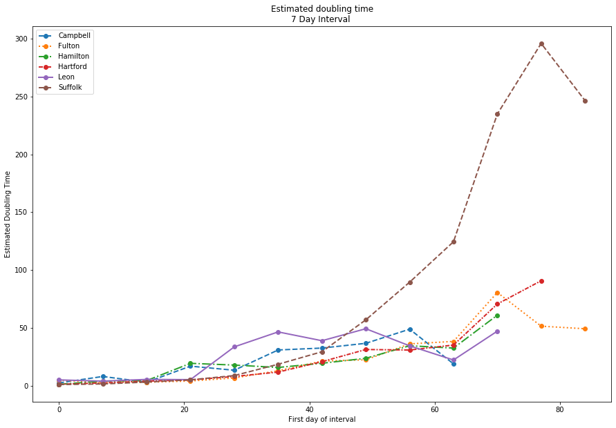

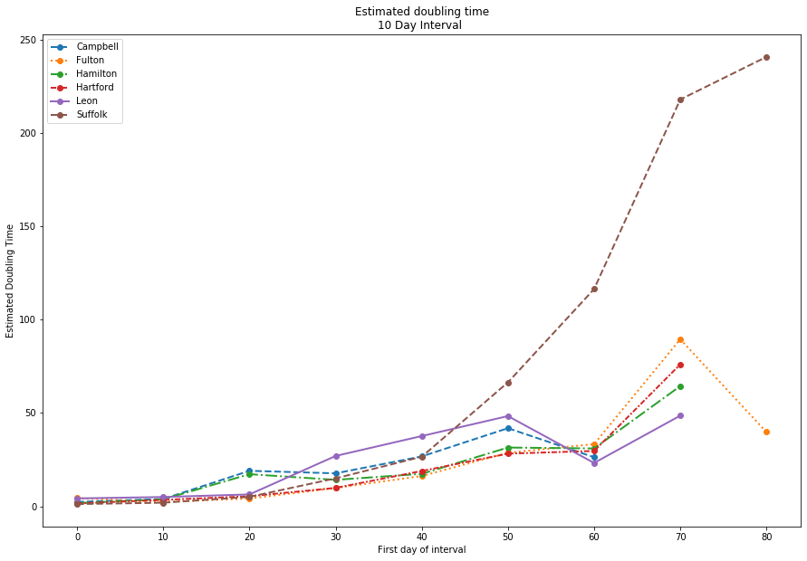

## Examine new cases, moving averages

While it is still difficult to examine the evolution for the small counties (Leon and Campbell) but there is now a sizable amount of information in terms of the number of days since the first confirmed case. The following graphs show moving averages of the number of new confirmed cases. I did 5, 7, and 10 day moving averages.  
All of the averages are 'trailing' in that the point on the graph represents the average number of new confirmed cases for that day and the $k-1$ previous days ($k = 5,7,10$).

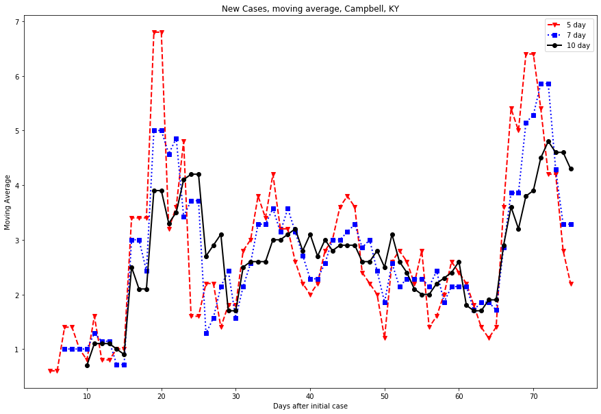

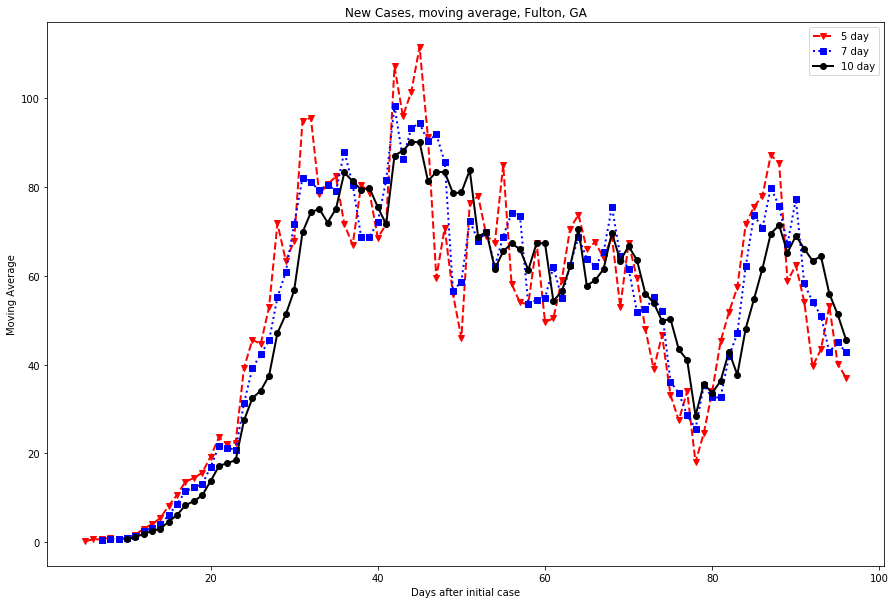

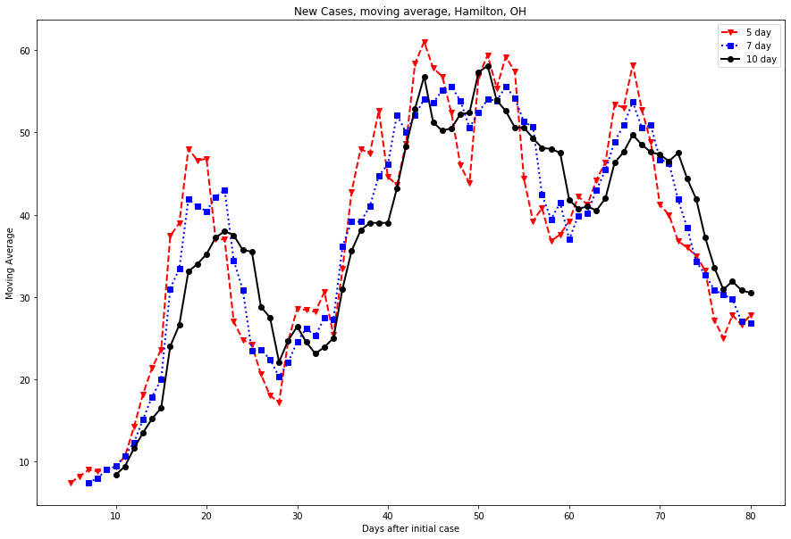

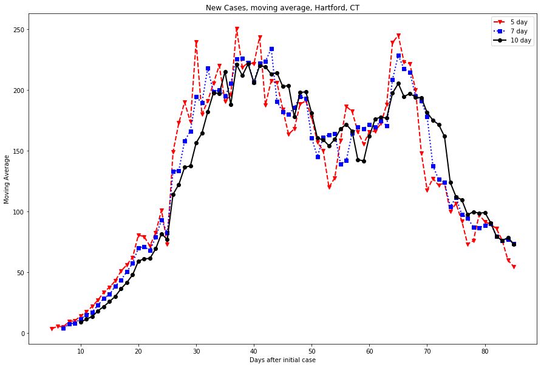

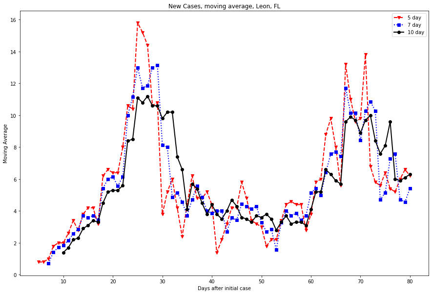

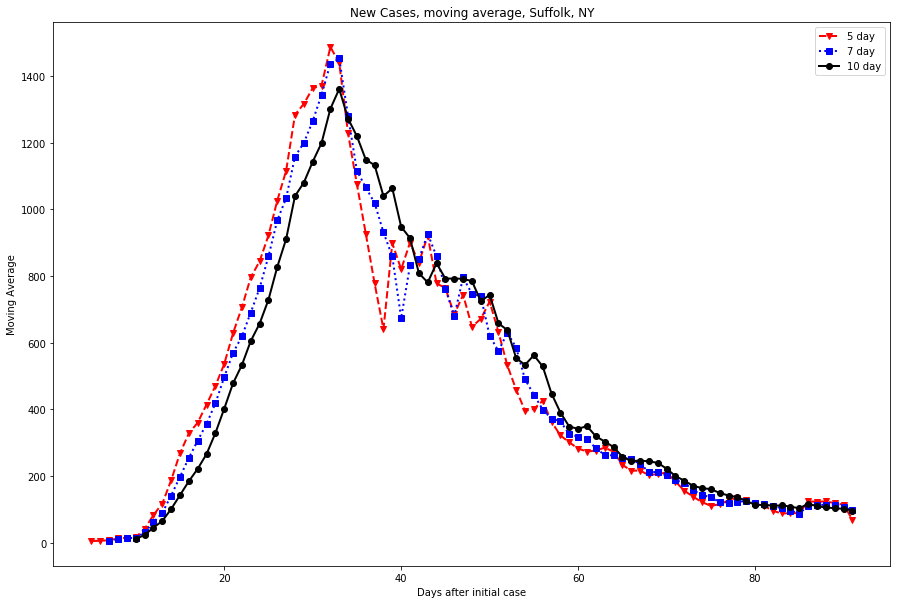

### References

If I keep going with this, I really need to acknowledge source of ideas, so I'm going to put those references here.  
The idea for using doubling time came from the SAS Blog,The Do Loop, written by Rick Wicklin.: https://blogs.sas.com/content/iml/2020/04/01/estimate-doubling-time-exponential-growth.html?utm_source=feedburner&utm_medium=email&utm_campaign=Feed%3A+TheDoLoop+%28The+DO+Loop%29